# Example evaluation of FOCUS Laboratory Data L1 to L3

## Laboratory Data L1

The following code defines example dataset L1 from the FOCUS kinetics report, p. 284:

```r
library("mkin")
FOCUS_2006_L1 = data.frame(
  t = rep(c(0, 1, 2, 3, 5, 7, 14, 21, 30), each = 2),
  parent = c(88.3, 91.4, 85.6, 84.5, 78.9, 77.6,
             72.0, 71.9, 50.3, 59.4, 47.0, 45.1,
             27.7, 27.3, 10.0, 10.4, 2.9, 4.0))
FOCUS_2006_L1_mkin <- mkin_wide_to_long(FOCUS_2006_L1)
```

Here we use the assumptions of simple first order (SFO), the case of declining rate constant over time (FOMC) and the case of two different phases of the kinetics (DFOP). For a more detailed discussion of the models, please see the FOCUS kinetics report.

Since mkin version 0.9-32 (July 2014), we can use shorthand notation like `SFO` for parent only degradation models. The following two lines fit the model and produce the summary report of the model fit. This covers the numerical analysis given in the FOCUS report.

```r
m.L1.SFO <- mkinfit("SFO", FOCUS_2006_L1_mkin, quiet=TRUE)
summary(m.L1.SFO)
```

```
## mkin version:    0.9.36
## R version:       3.2.1
## Date of fit:     Sun Jun 21 01:41:58 2015
## Date of summary: Sun Jun 21 01:41:58 2015
##
## Equations:
## d_parent = - k_parent_sink * parent
##
## Model predictions using solution type analytical
##
## Fitted with method Port using 37 model solutions performed in 0.086 s
##
## Weighting: none
##
## Starting values for parameters to be optimised:
##               value   type
## parent_0      89.85  state
## k_parent_sink  0.10 deparm
##
## Starting values for the transformed parameters actually optimised:
##                       value lower upper
## parent_0          89.850000  -Inf   Inf
## log_k_parent_sink -2.302585  -Inf   Inf
##
## Fixed parameter values:
## None
##
## Optimised, transformed parameters with symmetric confidence intervals:
##                   Estimate Std. Error  Lower  Upper
## parent_0            92.470    1.36800 89.570 95.370
## log_k_parent_sink   -2.347    0.04057 -2.433 -2.261
##
## Parameter correlation:
##                   parent_0 log_k_parent_sink
## parent_0            1.0000            0.6248
## log_k_parent_sink   0.6248            1.0000
##
## Residual standard error: 2.948 on 16 degrees of freedom
##
## Backtransformed parameters:
```

[output cut: 25 more lines]

```
##     1   parent     84.5    84.039   0.4610
##     2   parent     78.9    76.376   2.5241
##     2   parent     77.6    76.376   1.2241
##     3   parent     72.0    69.412   2.5884
##     3   parent     71.9    69.412   2.4884
##     5   parent     50.3    57.330  -7.0301
##     5   parent     59.4    57.330   2.0699
##     7   parent     47.0    47.352  -0.3515
##     7   parent     45.1    47.352  -2.2515
##    14   parent     27.7    24.247   3.4528
##    14   parent     27.3    24.247   3.0528
##    21   parent     10.0    12.416  -2.4163
##    21   parent     10.4    12.416  -2.0163
##    30   parent      2.9     5.251  -2.3513
##    30   parent      4.0     5.251  -1.2513
```

A plot of the fit is obtained with the plot function for mkinfit objects.

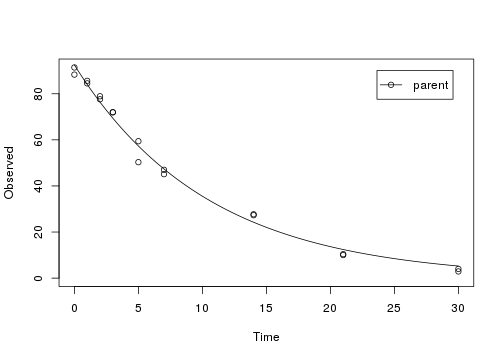

```r
plot(m.L1.SFO)
```

The residual plot can be easily obtained by

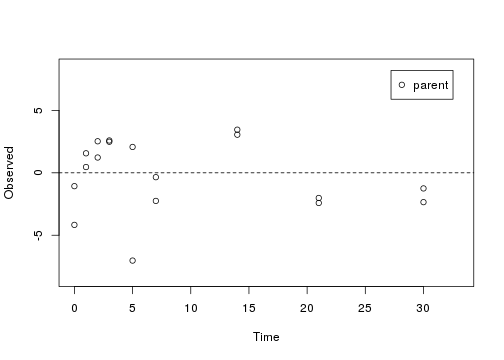

```r
mkinresplot(m.L1.SFO, ylab = "Observed", xlab = "Time")
```

For comparison, the FOMC model is fitted as well, and the chi<sup>2</sup> error level is checked.

```r
m.L1.FOMC <- mkinfit("FOMC", FOCUS_2006_L1_mkin, quiet=TRUE)
summary(m.L1.FOMC, data = FALSE)
```

```
## mkin version:    0.9.36
## R version:       3.2.1
## Date of fit:     Sun Jun 21 01:41:58 2015
## Date of summary: Sun Jun 21 01:41:58 2015
##
##
## Warning: Optimisation by method Port did not converge.
## Convergence code is 1
##
##
## Equations:
## d_parent = - (alpha/beta) * 1/((time/beta) + 1) * parent
##
## Model predictions using solution type analytical
##
## Fitted with method Port using 188 model solutions performed in 0.414 s
##
## Weighting: none
##
## Starting values for parameters to be optimised:
##          value   type
## parent_0 89.85  state
## alpha     1.00 deparm
## beta     10.00 deparm
##
## Starting values for the transformed parameters actually optimised:
##               value lower upper
## parent_0  89.850000  -Inf   Inf
## log_alpha  0.000000  -Inf   Inf
## log_beta   2.302585  -Inf   Inf
##
## Fixed parameter values:
## None
##
## Optimised, transformed parameters with symmetric confidence intervals:
##           Estimate Std. Error  Lower Upper
## parent_0     92.47      1.422  89.44 95.50
## log_alpha    15.43     15.080 -16.71 47.58
## log_beta     17.78     15.090 -14.37 49.93
##
```

[output cut: 10 more lines]

```
##   t-test (unrealistically) based on the assumption of normal distribution
##   for estimators of untransformed parameters.
##           Estimate t value    Pr(>t)     Lower     Upper
## parent_0 9.247e+01  65.150 4.044e-20 8.944e+01 9.550e+01
## alpha    5.044e+06   1.271 1.115e-01 5.510e-08 4.618e+20
## beta     5.276e+07   1.259 1.137e-01 5.732e-07 4.857e+21
##
## Chi2 error levels in percent:
##          err.min n.optim df
## All data   3.619       3  6
## parent     3.619       3  6
##
## Estimated disappearance times:
##        DT50  DT90 DT50back
## parent 7.25 24.08     7.25
```

The chi<sup>2</sup> error levels reported in Appendix 3 and Appendix 7 to the FOCUS kinetics report are rounded to integer percentages and partly deviate by one percentage point from the results calculated by mkin. The reason for this is not known. However, mkin gives the same chi<sup>2</sup> error levels as the kinfit package. Furthermore, the calculation routines of the kinfit package have been extensively compared to the results obtained by the KinGUI software, as documented in the kinfit package vignette. KinGUI is a widely used standard package in this field.

## Laboratory Data L2

The following code defines example dataset L2 from the FOCUS kinetics report, p. 287:

```r
FOCUS_2006_L2 = data.frame(
  t = rep(c(0, 1, 3, 7, 14, 28), each = 2),
  parent = c(96.1, 91.8, 41.4, 38.7,
             19.3, 22.3, 4.6, 4.6,
             2.6, 1.2, 0.3, 0.6))
FOCUS_2006_L2_mkin <- mkin_wide_to_long(FOCUS_2006_L2)
```

Again, the SFO model is fitted and a summary is obtained:

```r
m.L2.SFO <- mkinfit("SFO", FOCUS_2006_L2_mkin, quiet=TRUE)
summary(m.L2.SFO)
```

```
## mkin version:    0.9.36
## R version:       3.2.1
## Date of fit:     Sun Jun 21 01:41:59 2015
## Date of summary: Sun Jun 21 01:41:59 2015
##
## Equations:
## d_parent = - k_parent_sink * parent
##
## Model predictions using solution type analytical
##
## Fitted with method Port using 41 model solutions performed in 0.09 s
##
## Weighting: none
##
## Starting values for parameters to be optimised:
##               value   type
## parent_0      93.95  state
## k_parent_sink  0.10 deparm
##
## Starting values for the transformed parameters actually optimised:
##                       value lower upper
## parent_0          93.950000  -Inf   Inf
## log_k_parent_sink -2.302585  -Inf   Inf
##
## Fixed parameter values:
## None
##
## Optimised, transformed parameters with symmetric confidence intervals:
##                   Estimate Std. Error   Lower   Upper
## parent_0           91.4700     3.8070 82.9800 99.9500
## log_k_parent_sink  -0.4112     0.1074 -0.6505 -0.1719
##
## Parameter correlation:
##                   parent_0 log_k_parent_sink
## parent_0            1.0000            0.4295
## log_k_parent_sink   0.4295            1.0000
##
## Residual standard error: 5.51 on 10 degrees of freedom
##
## Backtransformed parameters:
```

[output cut: 19 more lines]

```
##
## Data:
##  time variable observed predicted residual
##     0   parent     96.1 9.147e+01   4.6343
##     0   parent     91.8 9.147e+01   0.3343
##     1   parent     41.4 4.714e+01  -5.7394
##     1   parent     38.7 4.714e+01  -8.4394
##     3   parent     19.3 1.252e+01   6.7790
##     3   parent     22.3 1.252e+01   9.7790
##     7   parent      4.6 8.834e-01   3.7166
##     7   parent      4.6 8.834e-01   3.7166
##    14   parent      2.6 8.532e-03   2.5915
##    14   parent      1.2 8.532e-03   1.1915
##    28   parent      0.3 7.958e-07   0.3000
##    28   parent      0.6 7.958e-07   0.6000
```

The chi<sup>2</sup> error level of 14% suggests that the model does not fit very well. This is also obvious from the plots of the fit and the residuals.

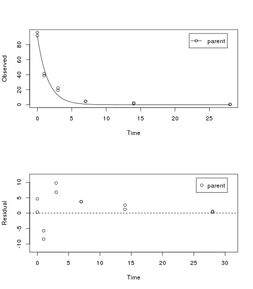

```r
par(mfrow = c(2, 1))
plot(m.L2.SFO)
mkinresplot(m.L2.SFO)
```

In the FOCUS kinetics report, it is stated that there is no apparent systematic error observed from the residual plot up to the measured DT90 (approximately at day 5), and there is an underestimation beyond that point.

We may add that it is difficult to judge the random nature of the residuals just from the three samplings at days 0, 1 and 3. Also, it is not clear *a priori* why a consistent underestimation after the approximate DT90 should be irrelevant. However, this can be rationalised by the fact that the FOCUS fate models generally only implement SFO kinetics.

For comparison, the FOMC model is fitted as well, and the chi<sup>2</sup> error level is checked.

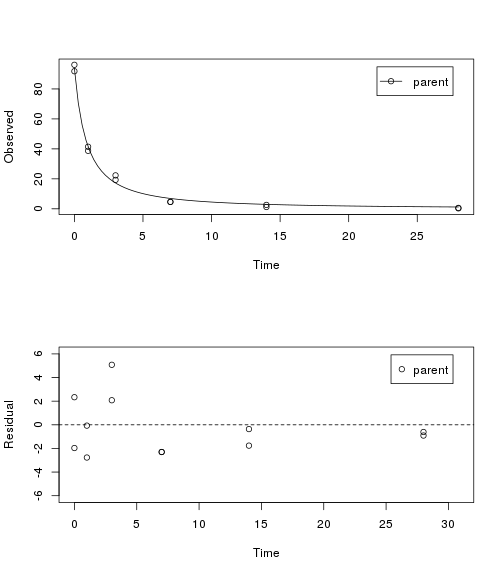

```r
m.L2.FOMC <- mkinfit("FOMC", FOCUS_2006_L2_mkin, quiet = TRUE)
par(mfrow = c(2, 1))
plot(m.L2.FOMC)
mkinresplot(m.L2.FOMC)
```

```r
summary(m.L2.FOMC, data = FALSE)
```

```
## mkin version:    0.9.36
## R version:       3.2.1
## Date of fit:     Sun Jun 21 01:41:59 2015
## Date of summary: Sun Jun 21 01:41:59 2015
##
## Equations:
## d_parent = - (alpha/beta) * 1/((time/beta) + 1) * parent
##
## Model predictions using solution type analytical
##
## Fitted with method Port using 81 model solutions performed in 0.17 s
##
## Weighting: none
##
## Starting values for parameters to be optimised:
##          value   type
## parent_0 93.95  state
## alpha     1.00 deparm
## beta     10.00 deparm
##
## Starting values for the transformed parameters actually optimised:
##               value lower upper
## parent_0  93.950000  -Inf   Inf
## log_alpha  0.000000  -Inf   Inf
## log_beta   2.302585  -Inf   Inf
##
## Fixed parameter values:
## None
##
## Optimised, transformed parameters with symmetric confidence intervals:
##           Estimate Std. Error   Lower   Upper
## parent_0   93.7700     1.8560 89.5700 97.9700
## log_alpha   0.3180     0.1867 -0.1044  0.7405
## log_beta    0.2102     0.2943 -0.4555  0.8759
##
## Parameter correlation:
##           parent_0 log_alpha log_beta
## parent_0   1.00000  -0.09553  -0.1863
## log_alpha -0.09553   1.00000   0.9757
## log_beta  -0.18628   0.97567   1.0000
##
## Residual standard error: 2.628 on 9 degrees of freedom
##
## Backtransformed parameters:
##   Confidence intervals for internally transformed parameters are asymmetric.
##   t-test (unrealistically) based on the assumption of normal distribution
##   for estimators of untransformed parameters.
##          Estimate t value    Pr(>t)   Lower  Upper
## parent_0   93.770  50.510 1.173e-12 89.5700 97.970
## alpha       1.374   5.355 2.296e-04  0.9009  2.097
## beta        1.234   3.398 3.949e-03  0.6341  2.401
##
## Chi2 error levels in percent:
##          err.min n.optim df
## All data   6.205       3  3
## parent     6.205       3  3
##
## Estimated disappearance times:
##          DT50  DT90 DT50back
## parent 0.8092 5.356    1.612
```

The error level at which the chi<sup>2</sup> test passes is much lower in this case. Therefore, the FOMC model provides a better description of the data, as less experimental error has to be assumed in order to explain the data.

Fitting the four parameter DFOP model further reduces the chi<sup>2</sup> error level.

[figure not shown]

```r
m.L2.DFOP <- mkinfit("DFOP", FOCUS_2006_L2_mkin, quiet = TRUE)
plot(m.L2.DFOP)
```

Here, the default starting parameters for the DFOP model obviously do not lead to a reasonable solution. Therefore the fit is repeated with different starting parameters.

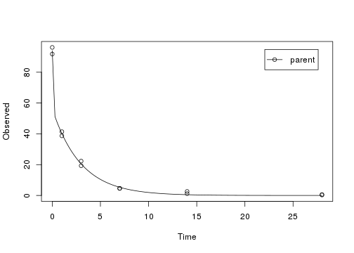

```r
m.L2.DFOP <- mkinfit("DFOP", FOCUS_2006_L2_mkin,
  parms.ini = c(k1 = 1, k2 = 0.01, g = 0.8),
  quiet=TRUE)
plot(m.L2.DFOP)
```

```r
summary(m.L2.DFOP, data = FALSE)
```

```
## mkin version:    0.9.36
## R version:       3.2.1
## Date of fit:     Sun Jun 21 01:42:01 2015
## Date of summary: Sun Jun 21 01:42:01 2015
##
## Equations:
## d_parent = - ((k1 * g * exp(-k1 * time) + k2 * (1 - g) * exp(-k2 *
##            time)) / (g * exp(-k1 * time) + (1 - g) * exp(-k2 *
##            time))) * parent
##
## Model predictions using solution type analytical
##
## Fitted with method Port using 336 model solutions performed in 0.738 s
##
## Weighting: none
##
## Starting values for parameters to be optimised:
##          value   type
## parent_0 93.95  state
## k1        1.00 deparm
## k2        0.01 deparm
## g         0.80 deparm
##
## Starting values for the transformed parameters actually optimised:
##               value lower upper
## parent_0 93.9500000  -Inf   Inf
## log_k1    0.0000000  -Inf   Inf
## log_k2   -4.6051702  -Inf   Inf
## g_ilr     0.9802581  -Inf   Inf
##
## Fixed parameter values:
## None
##
## Optimised, transformed parameters with symmetric confidence intervals:
##          Estimate Std. Error Lower Upper
## parent_0  93.9500         NA    NA    NA
## log_k1     3.1210         NA    NA    NA
## log_k2    -1.0880         NA    NA    NA
## g_ilr     -0.2821         NA    NA    NA
##
```

[output cut: 8 more lines]

```
##   for estimators of untransformed parameters.
##          Estimate t value Pr(>t) Lower Upper
## parent_0  93.9500      NA     NA    NA    NA
## k1        22.6700      NA     NA    NA    NA
## k2         0.3369      NA     NA    NA    NA
## g          0.4016      NA     NA    NA    NA
##
## Chi2 error levels in percent:
##          err.min n.optim df
## All data    2.53       4  2
## parent      2.53       4  2
##
## Estimated disappearance times:
##        DT50 DT90 DT50_k1 DT50_k2
## parent   NA   NA 0.03058   2.058
```

Here, the DFOP model is clearly the best-fit model for dataset L2 based on the chi<sup>2</sup> error level criterion. However, the failure to calculate the covariance matrix indicates that the parameter estimates correlate excessively. Therefore, the FOMC model may be preferred for this dataset.

## Laboratory Data L3

The following code defines example dataset L3 from the FOCUS kinetics report, p. 290.

```r
FOCUS_2006_L3 = data.frame(
  t = c(0, 3, 7, 14, 30, 60, 91, 120),
  parent = c(97.8, 60, 51, 43, 35, 22, 15, 12))
FOCUS_2006_L3_mkin <- mkin_wide_to_long(FOCUS_2006_L3)
```

SFO model, summary and plot:

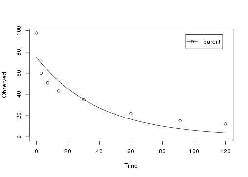

```r
m.L3.SFO <- mkinfit("SFO", FOCUS_2006_L3_mkin, quiet = TRUE)
plot(m.L3.SFO)
```

```r
summary(m.L3.SFO)
```

```
## mkin version:    0.9.36
## R version:       3.2.1
## Date of fit:     Sun Jun 21 01:42:01 2015
## Date of summary: Sun Jun 21 01:42:01 2015
##
## Equations:
## d_parent = - k_parent_sink * parent
##
## Model predictions using solution type analytical
##
## Fitted with method Port using 43 model solutions performed in 0.096 s
##
## Weighting: none
##
## Starting values for parameters to be optimised:
##               value   type
## parent_0       97.8  state
## k_parent_sink   0.1 deparm
##
## Starting values for the transformed parameters actually optimised:
##                       value lower upper
## parent_0          97.800000  -Inf   Inf
## log_k_parent_sink -2.302585  -Inf   Inf
##
## Fixed parameter values:
## None
##
## Optimised, transformed parameters with symmetric confidence intervals:
##                   Estimate Std. Error  Lower Upper
## parent_0            74.870     8.4570 54.180 95.57
## log_k_parent_sink   -3.678     0.3261 -4.476 -2.88
##
## Parameter correlation:
##                   parent_0 log_k_parent_sink
## parent_0            1.0000            0.5483
## log_k_parent_sink   0.5483            1.0000
##
## Residual standard error: 12.91 on 6 degrees of freedom
##
## Backtransformed parameters:
```

[output cut: 15 more lines]

```
##
## Estimated disappearance times:
##         DT50  DT90
## parent 27.43 91.13
##
## Data:
##  time variable observed predicted residual
##     0   parent     97.8    74.872  22.9281
##     3   parent     60.0    69.406  -9.4061
##     7   parent     51.0    62.734 -11.7340
##    14   parent     43.0    52.564  -9.5638
##    30   parent     35.0    35.084  -0.0839
##    60   parent     22.0    16.440   5.5602
##    91   parent     15.0     7.511   7.4887
##   120   parent     12.0     3.610   8.3903
```

The chi<sup>2</sup> error level of 21% as well as the plot suggest that the model does not fit very well.

The FOMC model performs better:

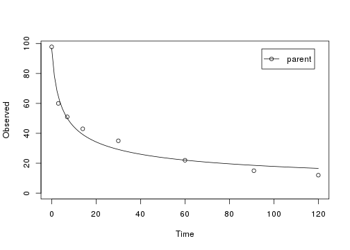

```r
m.L3.FOMC <- mkinfit("FOMC", FOCUS_2006_L3_mkin, quiet = TRUE)
plot(m.L3.FOMC)
```

```r
summary(m.L3.FOMC, data = FALSE)
```

```
## mkin version:    0.9.36
## R version:       3.2.1
## Date of fit:     Sun Jun 21 01:42:01 2015
## Date of summary: Sun Jun 21 01:42:01 2015
##
## Equations:
## d_parent = - (alpha/beta) * 1/((time/beta) + 1) * parent
##
## Model predictions using solution type analytical
##
## Fitted with method Port using 83 model solutions performed in 0.173 s
##
## Weighting: none
##
## Starting values for parameters to be optimised:
##          value   type
## parent_0  97.8  state
## alpha      1.0 deparm
## beta      10.0 deparm
##
## Starting values for the transformed parameters actually optimised:
##               value lower upper
## parent_0  97.800000  -Inf   Inf
## log_alpha  0.000000  -Inf   Inf
## log_beta   2.302585  -Inf   Inf
##
## Fixed parameter values:
## None
##
## Optimised, transformed parameters with symmetric confidence intervals:
##           Estimate Std. Error   Lower    Upper
## parent_0   96.9700     4.5500 85.2800 108.7000
## log_alpha  -0.8619     0.1704 -1.3000  -0.4238
## log_beta    0.6193     0.4744 -0.6003   1.8390
##
## Parameter correlation:
##           parent_0 log_alpha log_beta
## parent_0    1.0000   -0.1512  -0.4271
## log_alpha  -0.1512    1.0000   0.9110
## log_beta   -0.4271    0.9110   1.0000
##
## Residual standard error: 4.572 on 5 degrees of freedom
##
## Backtransformed parameters:
##   Confidence intervals for internally transformed parameters are asymmetric.
##   t-test (unrealistically) based on the assumption of normal distribution
##   for estimators of untransformed parameters.
##          Estimate t value    Pr(>t)   Lower    Upper
## parent_0  96.9700  21.310 2.108e-06 85.2800 108.7000
## alpha      0.4224   5.867 1.020e-03  0.2725   0.6546
## beta       1.8580   2.108 4.444e-02  0.5487   6.2890
##
## Chi2 error levels in percent:
##          err.min n.optim df
## All data    7.32       3  5
## parent      7.32       3  5
##
## Estimated disappearance times:
##         DT50  DT90 DT50back
## parent 7.729 431.2    129.8
```

The error level at which the chi<sup>2</sup> test passes is 7% in this case.

Fitting the four parameter DFOP model further reduces the chi<sup>2</sup> error level considerably:

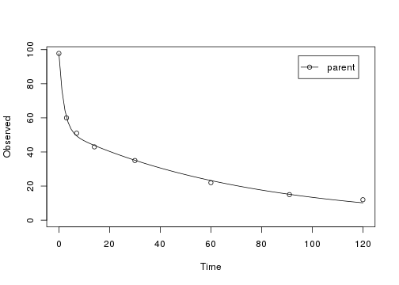

```r
m.L3.DFOP <- mkinfit("DFOP", FOCUS_2006_L3_mkin, quiet = TRUE)
plot(m.L3.DFOP)
```

```r
summary(m.L3.DFOP, data = FALSE)
```

```
## mkin version:    0.9.36
## R version:       3.2.1
## Date of fit:     Sun Jun 21 01:42:01 2015
## Date of summary: Sun Jun 21 01:42:01 2015
##
## Equations:
## d_parent = - ((k1 * g * exp(-k1 * time) + k2 * (1 - g) * exp(-k2 *
##            time)) / (g * exp(-k1 * time) + (1 - g) * exp(-k2 *
##            time))) * parent
##
## Model predictions using solution type analytical
##
## Fitted with method Port using 137 model solutions performed in 0.302 s
##
## Weighting: none
##
## Starting values for parameters to be optimised:
##          value   type
## parent_0 97.80  state
## k1        0.10 deparm
## k2        0.01 deparm
## g         0.50 deparm
##
## Starting values for the transformed parameters actually optimised:
##              value lower upper
## parent_0 97.800000  -Inf   Inf
## log_k1   -2.302585  -Inf   Inf
## log_k2   -4.605170  -Inf   Inf
## g_ilr     0.000000  -Inf   Inf
##
## Fixed parameter values:
## None
##
## Optimised, transformed parameters with symmetric confidence intervals:
##          Estimate Std. Error   Lower     Upper
## parent_0  97.7500    1.43800 93.7500 101.70000
## log_k1    -0.6612    0.13340 -1.0310  -0.29100
## log_k2    -4.2860    0.05902 -4.4500  -4.12200
## g_ilr     -0.1229    0.05121 -0.2651   0.01925
##
```

[output cut: 12 more lines]

```
##   for estimators of untransformed parameters.
##          Estimate t value    Pr(>t)    Lower     Upper
## parent_0 97.75000  67.970 1.404e-07 93.75000 101.70000
## k1        0.51620   7.499 8.460e-04  0.35650   0.74750
## k2        0.01376  16.940 3.557e-05  0.01168   0.01621
## g         0.45660  25.410 7.121e-06  0.40730   0.50680
##
## Chi2 error levels in percent:
##          err.min n.optim df
## All data   2.225       4  4
## parent     2.225       4  4
##
## Estimated disappearance times:
##         DT50 DT90 DT50_k1 DT50_k2
## parent 7.464  123   1.343   50.37
```

Here, a look to the model plot, the confidence intervals of the parameters and the correlation matrix suggest that the parameter estimates are reliable, and the DFOP model can be used as the best-fit model based on the chi<sup>2</sup> error level criterion for laboratory data L3.

This is also an example where the standard t-test for the parameter `g_ilr` is misleading, as it tests for a significant difference from zero. In this case, zero appears to be the correct value for this parameter, and the confidence interval for the backtransformed parameter `g` is quite narrow.

## Laboratory Data L4

The following code defines example dataset L4 from the FOCUS kinetics report, p. 293:

```r
FOCUS_2006_L4 = data.frame(
  t = c(0, 3, 7, 14, 30, 60, 91, 120),
  parent = c(96.6, 96.3, 94.3, 88.8, 74.9, 59.9, 53.5, 49.0))
FOCUS_2006_L4_mkin <- mkin_wide_to_long(FOCUS_2006_L4)
```

SFO model, summary and plot:

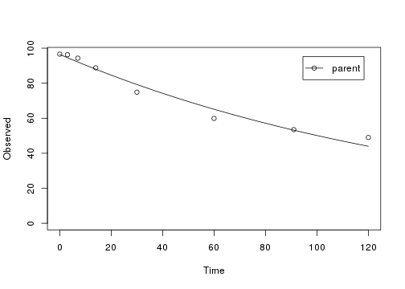

```r
m.L4.SFO <- mkinfit("SFO", FOCUS_2006_L4_mkin, quiet = TRUE)
plot(m.L4.SFO)
```

```r
summary(m.L4.SFO, data = FALSE)
```

```
## mkin version:    0.9.36
## R version:       3.2.1
## Date of fit:     Sun Jun 21 01:42:02 2015
## Date of summary: Sun Jun 21 01:42:02 2015
##
## Equations:
## d_parent = - k_parent_sink * parent
##
## Model predictions using solution type analytical
##
## Fitted with method Port using 46 model solutions performed in 0.104 s
##
## Weighting: none
##
## Starting values for parameters to be optimised:
##               value   type
## parent_0       96.6  state
## k_parent_sink   0.1 deparm
##
## Starting values for the transformed parameters actually optimised:
##                       value lower upper
## parent_0          96.600000  -Inf   Inf
## log_k_parent_sink -2.302585  -Inf   Inf
##
## Fixed parameter values:
## None
##
## Optimised, transformed parameters with symmetric confidence intervals:
##                   Estimate Std. Error  Lower   Upper
## parent_0             96.44    1.94900 91.670 101.200
## log_k_parent_sink    -5.03    0.07999 -5.225  -4.834
##
## Parameter correlation:
##                   parent_0 log_k_parent_sink
## parent_0            1.0000            0.5865
## log_k_parent_sink   0.5865            1.0000
##
## Residual standard error: 3.651 on 6 degrees of freedom
##
## Backtransformed parameters:
##   Confidence intervals for internally transformed parameters are asymmetric.
##   t-test (unrealistically) based on the assumption of normal distribution
##   for estimators of untransformed parameters.
##                Estimate t value    Pr(>t)     Lower     Upper
## parent_0      96.440000   49.49 2.283e-09 91.670000 1.012e+02
## k_parent_sink  0.006541   12.50 8.008e-06  0.005378 7.955e-03
##
## Chi2 error levels in percent:
##          err.min n.optim df
## All data   3.287       2  6
## parent     3.287       2  6
##
## Resulting formation fractions:
##             ff
## parent_sink  1
##
## Estimated disappearance times:
##        DT50 DT90
## parent  106  352
```

The chi<sup>2</sup> error level of 3.3% as well as the plot suggest that the model fits very well.

The FOMC model for comparison:

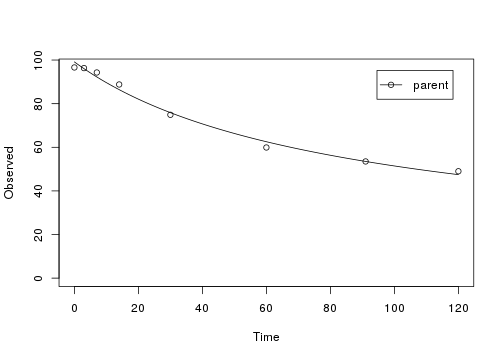

```r
m.L4.FOMC <- mkinfit("FOMC", FOCUS_2006_L4_mkin, quiet = TRUE)
plot(m.L4.FOMC)
```

```r
summary(m.L4.FOMC, data = FALSE)
```

```
## mkin version:    0.9.36
## R version:       3.2.1
## Date of fit:     Sun Jun 21 01:42:02 2015
## Date of summary: Sun Jun 21 01:42:02 2015
##
## Equations:
## d_parent = - (alpha/beta) * 1/((time/beta) + 1) * parent
##
## Model predictions using solution type analytical
##
## Fitted with method Port using 66 model solutions performed in 0.139 s
##
## Weighting: none
##
## Starting values for parameters to be optimised:
##          value   type
## parent_0  96.6  state
## alpha      1.0 deparm
## beta      10.0 deparm
##
## Starting values for the transformed parameters actually optimised:
##               value lower upper
## parent_0  96.600000  -Inf   Inf
## log_alpha  0.000000  -Inf   Inf
## log_beta   2.302585  -Inf   Inf
##
## Fixed parameter values:
## None
##
## Optimised, transformed parameters with symmetric confidence intervals:
##           Estimate Std. Error  Lower    Upper
## parent_0   99.1400     1.6800 94.820 103.5000
## log_alpha  -0.3506     0.3725 -1.308   0.6068
## log_beta    4.1740     0.5635  2.726   5.6230
##
## Parameter correlation:
##           parent_0 log_alpha log_beta
## parent_0    1.0000   -0.5365  -0.6083
## log_alpha  -0.5365    1.0000   0.9913
## log_beta   -0.6083    0.9913   1.0000
##
## Residual standard error: 2.315 on 5 degrees of freedom
##
## Backtransformed parameters:
##   Confidence intervals for internally transformed parameters are asymmetric.
##   t-test (unrealistically) based on the assumption of normal distribution
##   for estimators of untransformed parameters.
##          Estimate t value    Pr(>t)   Lower   Upper
## parent_0  99.1400  59.020 1.322e-08 94.8200 103.500
## alpha      0.7042   2.685 2.178e-02  0.2703   1.835
## beta      64.9800   1.775 6.807e-02 15.2600 276.600
##
## Chi2 error levels in percent:
##          err.min n.optim df
## All data   2.029       3  5
## parent     2.029       3  5
##
## Estimated disappearance times:
##         DT50 DT90 DT50back
## parent 108.9 1644    494.9
```

The error level at which the chi<sup>2</sup> test passes is slightly lower for the FOMC model. However, the difference appears negligible.